# Esercitazione N.4

- Mostra il codice
- Nascondere il codice
- Vedere il codice

Nonlinearità: polinomi

Autore/Autrice

Andrea Recine

Data di Pubblicazione

5 maggio 2026

## 1 Setup:

```r
library(tidyverse)
library(knitr)
library(tinytable)
library(modelsummary)
library(fixest)
library(wooldridge)
```

## 2 Introduzione

Siamo interessati agli effetti degli anni di esperienza sul salario orario ($wage$). Il polinomio quadratico è spesso utilizzato in applicazioni economiche per catturare effetti marginali crescenti e decrescenti.

In questo caso $\beta_1$ è positivo e $\beta_2$ negativo.

```r
reg_wage_exper <- feols(wage ~ exper + exper^2, data = wage1, vcov = "hetero")
modelsummary(list("Wage" = reg_wage_exper), gof_omit = "AIC|BIC|RMSE|R2 Adj.")
```

|  | Wage |
| --- | --- |
| (Intercept) | 3.725 |
|  | (0.252) |
| exper | 0.298 |
|  | (0.039) |
| I(exper^2) | -0.006 |
|  | (0.001) |
| Num.Obs. | 526 |
| R2 | 0.093 |

**ImportanteSintassi `^2` vs `I(^2)`**

Nelle formule di R, l’operatore `^` **non significa “elevato al quadrato”**: indica le interazioni fino a un certo ordine. Per questo, in *quasi tutti* i pacchetti di stima (`lm()`, `glm()`, `lme4`, …) per inserire un termine quadratico bisogna scriverlo dentro `I()` (“inhibit”), che dice a R di trattarlo come un’operazione aritmetica:

```r
lm(wage ~ exper + I(exper^2), data = wage1)
```

Se scrivessimo `lm(wage ~ exper + exper^2, ...)` la regressione girerebbe senza errori, ma stimerebbe **silenziosamente solo** $wage$ su $exper$ (senza il termine quadratico)!

`fixest` (la libreria che usiamo con `feols()`) è un’eccezione: riconosce automaticamente `^` come elevamento a potenza, quindi `exper^2` è **equivalente** a `I(exper^2)`.

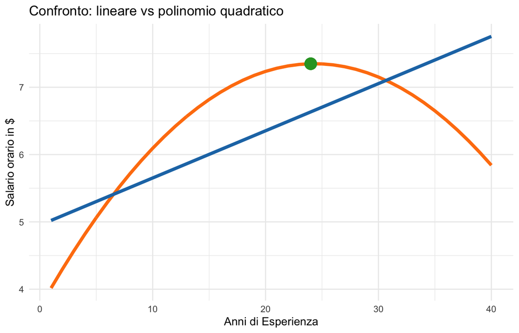

```r
# 1. Previsione dei valori stimati
wage1 <- wage1 %>%
  mutate(wageexp_pred = predict(reg_wage_exper))

# 2. Filtro per exper ≤ 40
wage_cut <- wage1 %>% filter(exper <= 40)

# 3. Trova il punto massimo della curva wageexp_pred
punto_max <- wage_cut %>%
  filter(wageexp_pred == max(wageexp_pred, na.rm = TRUE))

# 4. Grafico
ggplot(wage_cut, aes(x = exper)) +
  geom_line(aes(y = wageexp_pred), color = "#ff7f0e", linewidth = 1.5) +              # curva stimata
  geom_smooth(aes(y = wage), method = "lm", se = FALSE, color = "#1f77b4", linewidth = 1.5) + # retta OLS
  geom_point(data = punto_max, aes(y = wageexp_pred), color = "#2ca02c", size = 5) +
  labs(
    title = "Confronto: lineare vs polinomio quadratico",
    x = "Anni di Esperienza",
    y = "Salario orario in $"
  ) +
  theme_minimal()
```

```r
reg_wage_exper2 <- feols(wage ~ exper + exper^2 + educ + tenure, data = wage1, vcov = "hetero")
modelsummary(list("Wage" = reg_wage_exper, "Wage" = reg_wage_exper2), gof_omit = "AIC|BIC|RMSE|R2 Adj.")
```

|  | Wage | Wage |
| --- | --- | --- |
| (Intercept) | 3.725 | -3.420 |
|  | (0.252) | (0.780) |
| exper | 0.298 | 0.205 |
|  | (0.039) | (0.032) |
| I(exper^2) | -0.006 | -0.004 |
|  | (0.001) | (0.001) |
| educ |  | 0.556 |
|  |  | (0.059) |
| tenure |  | 0.161 |
|  |  | (0.028) |
| Num.Obs. | 526 | 526 |
| R2 | 0.093 | 0.343 |

### 2.1 Interpretazione dei coefficienti:

**Consideriamo la prima regressione (prima colonna):** non possiamo interpretare il coefficiente associato a $\beta_1$ tenendo costante quello associato a $\beta_2$.

Per piccole variazioni di $x$, l’effetto *ceteris paribus* è descritto dall’effetto marginale, quindi:

Abbiamo che:

$$y = \beta_0 + \beta_1 x + \beta_2 x^2 + u$$

L’equazione stimata è:

$$\hat{y} = \hat{\beta_0} + \hat{\beta_1} x + \hat{\beta_2} x^2$$

Otteniamo la seguente approssimazione in variazioni:

$$\Delta \hat{y} \approx (\hat{\beta_1} + 2 \hat{\beta_2} x) \Delta x$$

e quindi l’effetto marginale è:

$$\Delta \hat{y}/ \Delta x \approx \hat{\beta_1} + 2 \hat{\beta_2} x$$

Nel nostro esempio:

- L’effetto marginale per un lavoratore con un anno di esperienza è: $0.298 - (2* 0.006) * 1 = 0.286$
- L’effetto marginale a 10 anni di esperienza: $0.298 - 2(0.006) *10 = 0.178$

Una variazione discreta di $\Delta x$ (da 1 a 2 anni di esperienza):

$$\Delta \hat{Y} = (\hat{\beta_0} + \hat{\beta_1} \cdot 2 + \hat{\beta_2} \cdot 2^{2}) - (\hat{\beta_0} + \hat{\beta_1} \cdot 1 + \hat{\beta_2} \cdot 1^{2})$$

Uguale a $4.297 - 4.017 = 0.28$ dollari

Considerando da una variazione discreta da 10 a 11 anni di esperienza:

- *10 anni*: $3.725 + 2.98 - 0.006 (100)$
- *11 anni*: $3.725 + 3.278 - 0.006 (121)$ $\Delta \hat{Y} = 6.277 - 6.105 = 0.172$ dollari

**AttenzioneEffetto marginale e variazione discreta**

La formula $\Delta\hat{y}/\Delta x \approx \hat{\beta}_1 + 2\hat{\beta}_2 x$ è la **derivata** della funzione stimata valutata in $x$: misura la variazione di $\hat{y}$ per una variazione *infinitesima* di $x$.

Nel nostro esempio l’effetto marginale e la variazione discreta pari a $\Delta x = 1$ differiscono di $\hat{\beta}_2$, che in questo caso è piccolo ($-0.006$): infatti l’effetto marginale per un lavoratore con un anno di esperienza è $0.286$. La variazione discreta su $wage$ di passare da 1 a 2 anni è pari a $0.28$.

Quando la variazione di $x$ non è infinitesima, l’effetto dipende non solo dal punto di partenza $x$, ma anche dall’ampiezza della variazione stessa. La differenza è pari a $\hat{\beta}_2 \cdot (\Delta x)^2$ e diventa più grande al crescere di $\Delta x$. Nel nostro caso abbiamo considerato variazioni discrete di un anno, quindi $\Delta x = 1$ e la differenza è pari a $-0.006$, esattamente il coefficiente di $exper^2$.

In alcuni casi preferiamo l’approssimazione perché fornisce un **riassunto immediato** dell’effetto di $x$ su $y$: basta sostituire un valore di interesse per leggere l’effetto marginale in quel punto. Ma quando la variazione di $x$ discreta è molto ampia, è più corretto calcolare la variazione esatta, perché l’approssimazione potrebbe essere fuorviante.

**NotaTrovare il picco**

Quando $\hat{\beta_1} > 0$ e $\hat{\beta_2} < 0$, la curva stimata è una **parabola con la concavità verso il basso**: prima cresce, raggiunge un massimo, poi decresce. Lo si vede chiaramente nel grafico precedente (punto verde).

La derivata prima

$$\frac{d \hat{y}}{d x} = \hat{\beta_1} + 2 \hat{\beta_2} x$$

misura la pendenza della curva. Per $x$ piccoli è **positiva** (la curva sale); via via che $x$ aumenta diventa più piccola, finché incontra l’asse delle ascisse — cioè vale **zero** — esattamente nel punto di massimo. Oltre quella soglia diventa **negativa**: l’effetto marginale di un anno in più di esperienza sul salario predetto cambia di segno.

Visivamente, la derivata è una **retta decrescente** (perché $\hat{\beta_2} < 0$) che attraversa l’asse delle ascisse proprio in corrispondenza del picco della parabola:

**Mostra codice**

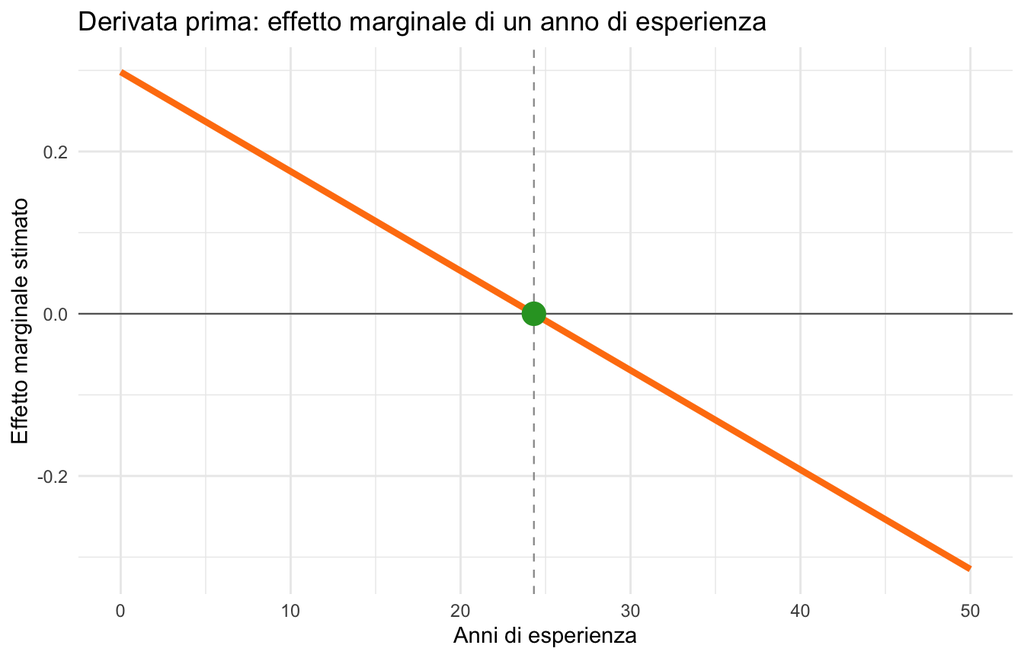

```r
b1 <- coef(reg_wage_exper)["exper"]
b2 <- coef(reg_wage_exper)["I(exper^2)"]
xstar <- -b1 / (2 * b2)

deriv_df <- tibble(
  exper = seq(0, 50, length.out = 200),
  d = b1 + 2 * b2 * exper
)

ggplot(deriv_df, aes(x = exper, y = d)) +
  geom_hline(yintercept = 0, color = "grey40", linewidth = 0.4) +
  geom_vline(xintercept = xstar, color = "grey60", linewidth = 0.4, linetype = "dashed") +
  geom_line(color = "#ff7f0e", linewidth = 1.5) +
  annotate("point", x = xstar, y = 0, color = "#2ca02c", size = 5) +
  labs(
    title = "Derivata prima: effetto marginale di un anno di esperienza",
    x = "Anni di esperienza",
    y = "Effetto marginale stimato"
  ) +
  theme_minimal()
```

Per trovare il picco basta porre $\frac{d \hat{y}}{d x} = 0$ e risolvere per $x$:

$$x^{*} = -\frac{\hat{\beta_1}}{2 \hat{\beta_2}}$$

Nel nostro modello:

$$x^{*} = -\frac{0.298}{2 \cdot (-0.006)} \approx 24.8 \text{ anni di esperienza}$$

## 3 Log e polinomi:

E se $wage$ fosse espresso in log? Consideriamo la seguente regressione:

```r
reg_logwage_exper <- feols(log(wage) ~ exper + exper^2 + educ + tenure, data = wage1, vcov = "hetero")
modelsummary(list("Wage" = reg_wage_exper, "Log Wage" = reg_logwage_exper), gof_omit = "AIC|BIC|RMSE|R2 Adj.")
```

|  | Wage | Log Wage |
| --- | --- | --- |
| (Intercept) | 3.725 | 0.198 |
|  | (0.252) | (0.105) |
| exper | 0.298 | 0.033 |
|  | (0.039) | (0.005) |
| I(exper^2) | -0.006 | -0.001 |
|  | (0.001) | (0.000) |
| educ |  | 0.085 |
|  |  | (0.008) |
| tenure |  | 0.021 |
|  |  | (0.004) |
| Num.Obs. | 526 | 526 |
| R2 | 0.093 | 0.359 |

**Secondo modello:** L’effetto marginale quando $exper = 0$ è pari a $0.033$, cioè un aumento del salario predetto di circa il 3.3%. Quindi il rendimento stimato di un anno aggiuntivo di esperienza su $wage$ per una persona con nessuna esperienza è di circa il 3.3%.

L’effetto marginale a 1 anno di esperienza (per un lavoratore con 1 anno di esperienza) è $0.033 - 2 \cdot 0.001 \cdot 1 = 0.031$, cioè un salario predetto **maggiore di circa il 3.1%**.

L’effetto marginale a 10 anni di esperienza è: $0.033 - 2 \cdot 0.001 \cdot 10 = 0.013$, cioè un aumento del salario predetto di circa l’1.3%.

## 4 In deviazione dalla media

Nella precedente regressione abbiamo visto che il coefficiente di $exper$ rappresenta l’effetto marginale per un lavoratore con zero anni di esperienza. In alcuni casi può essere utile considerare la deviazione dalla media. Creiamo una nuova variabile:

$$exper\_center = exper - media(exper)$$

```r
wage1 <- wage1 %>%
  mutate(exper_center = exper - mean(exper, na.rm = TRUE))
```

Intuizione dell’effetto della deviazione dalla media? Regressione semplice senza polinomio:

```r
reg_experc <- feols(wage ~ exper_center, data = wage1, vcov = "hetero")

reg_exper <- feols(wage ~ exper, data = wage1, vcov = "hetero")
modelsummary(list("Wage" = reg_experc, "Wage" = reg_exper), gof_omit = "AIC|BIC|RMSE|R2 Adj.")
```

|  | Wage | Wage |
| --- | --- | --- |
| (Intercept) | 5.896 | 5.373 |
|  | (0.160) | (0.204) |
| exper_center | 0.031 |  |
|  | (0.011) |  |
| exper |  | 0.031 |
|  |  | (0.011) |
| Num.Obs. | 526 | 526 |
| R2 | 0.013 | 0.013 |

Cosa cambia?

- **L’intercetta!** Perché nel primo modello rappresenta il salario predetto per un individuo con **esperienza uguale alla media**
- Nel secondo modello l’intercetta rappresenta il salario predetto con zero anni di esperienza.

Quindi esprimere $exper$ in deviazione dalla media ci permette di interpretare l’intercetta come il salario predetto per un individuo con esperienza media, invece che per un individuo senza esperienza.

## 5 Deviazione dalla media e polinomi

Nel caso di regressioni con polinomi, esprimere $exper$ in deviazione dalla media ci permette di interpretare il coefficiente di $exper\_center$ come l’incremento marginale del salario quando $exper$ è uguale alla media, invece che quando $exper$ è uguale a zero.

```r
reg_wagepolcenter <- feols(wage ~ educ + exper_center + exper_center^2 + tenure, data = wage1, vcov = "hetero")
reg_wagepol <- feols(wage ~ educ + exper + exper^2 + tenure, data = wage1, vcov = "hetero")

modelsummary(list("Wage" = reg_wagepolcenter, "Wage" = reg_wagepol), gof_omit = "AIC|BIC|RMSE|R2 Adj.")
```

|  | Wage | Wage |
| --- | --- | --- |
| (Intercept) | -1.146 | -3.420 |
|  | (0.743) | (0.780) |
| educ | 0.556 | 0.556 |
|  | (0.059) | (0.059) |
| exper_center | 0.062 |  |
|  | (0.012) |  |
| I(exper_center^2) | -0.004 |  |
|  | (0.001) |  |
| tenure | 0.161 | 0.161 |
|  | (0.028) | (0.028) |
| exper |  | 0.205 |
|  |  | (0.032) |
| I(exper^2) |  | -0.004 |
|  |  | (0.001) |
| Num.Obs. | 526 | 526 |
| R2 | 0.343 | 0.343 |

Ora il coefficiente di $exper\_center$ rappresenta l’incremento marginale del salario quando $exper$ è uguale alla media. I coefficienti delle altre variabili (**esclusa l’intercetta**) rimangono invariati.

Il coefficiente di $exper\_center$ uguale a 0.062 rappresenta l’incremento del salario quando $exper$ è uguale alla media, cioè quando $exper\_center$ è uguale a zero.

Invece, nel secondo modello (senza $exper\_center$), il coefficiente di $exper$ rappresenta l’incremento marginale del salario per un lavoratore con zero anni di esperienza.

Ricordate che:

$$exper\_center = exper - media(exper)$$

E le statistiche descrittive di $exper$:

```r
desc_exper <- wage1 %>%
  summarise(
    Media = mean(exper, na.rm = TRUE),
    Q1 = quantile(exper, 0.25, na.rm = TRUE),
    Mediana = median(exper, na.rm = TRUE),
    Q3 = quantile(exper, 0.75, na.rm = TRUE)
  )

tt(desc_exper, digits = 3)
```

| Media | Q1 | Mediana | Q3 |
| --- | --- | --- | --- |
| 17 | 5 | 13.5 | 26 |

La media di $exper$ è il valore che sottraiamo per ottenere $exper\_center$: per costruzione, quest’ultima ha **media zero**.

**AttenzioneCentratura e multicollinearità**

Oltre al vantaggio interpretativo che abbiamo visto, centrare $exper$ ha anche un vantaggio **computazionale**: riduce la multicollinearità tra il termine lineare e quello quadratico.

L’intuizione è la seguente. Se $exper$ varia in un intorno della sua media $\overline{exper}$, possiamo approssimare $exper^2$ con uno sviluppo del primo ordine attorno a $\overline{exper}$:

$$exper^2 \approx \overline{exper}^{\,2} + 2\,\overline{exper}\,(exper - \overline{exper}) = -\overline{exper}^{\,2} + 2\,\overline{exper}\cdot exper.$$

Quando $\overline{exper}$ è lontana da zero (nel nostro caso $\overline{exper} \approx 17$), $exper^2$ si comporta **quasi come una funzione lineare di $exper$**, con pendenza $2\,\overline{exper}$. I due regressori $exper$ ed $exper^2$ tendono perciò a muoversi insieme: per OLS diventa difficile separare il contributo di ciascuno, gli errori standard si gonfiano e il calcolo numerico è meno stabile.

Se invece usiamo $exper\_center = exper - \overline{exper}$, lo stesso sviluppo dà $exper\_center^2 \approx 0$ in prossimità della media: le potenze pari ($exper\_center^2$) e quelle dispari ($exper\_center$) tendono a essere **ortogonali tra loro**. La matrice dei regressori è meglio condizionata e gli errori standard si riducono.

Lo stesso argomento vale per polinomi di ordine superiore ($exper^3$, $exper^4$, …): centrare prima di elevare a potenza migliora sempre il condizionamento numerico.